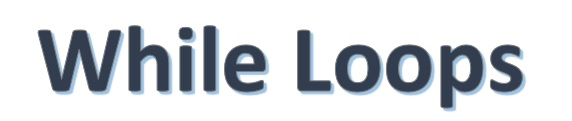

# While Loops

## Python's way to loop as long as the condition is true.

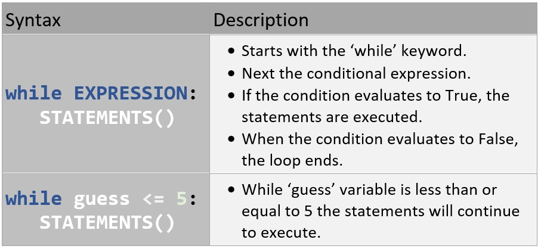

## While Loops:

### While loops are one of the fundamental pieces of programming. Python provides a while loop to execute statements an unknown number of times. The while loop syntax is symple but very powerful.

### Below, 'theNumber' variable is initialize and value set to 1. Then the loop is set to run as long as 'theNumber' is less than or equal to 5.

### Each time the loop evaluates to true the indented statements will be executed. The print() function is used to show the value of 'theNumber' each time the loop runs.

```python
theNumber = 1
while theNumber <= 5:
    print("The Number is", theNumber)
    theNumber += 1
```

### We initialize 'theNumber' variable and set its value to 1.

### while 'theNumber' variable is less than or equal to 5: Run print() statement, and Increment the 'theNumber' variable by 1.

### "The Number is 1" prints out.

### This keeps happening until the condition evaluates to false (i.e., theNumber = 6). When the condition evaluates to false the while loops stops/exits.

# Comparison Operators

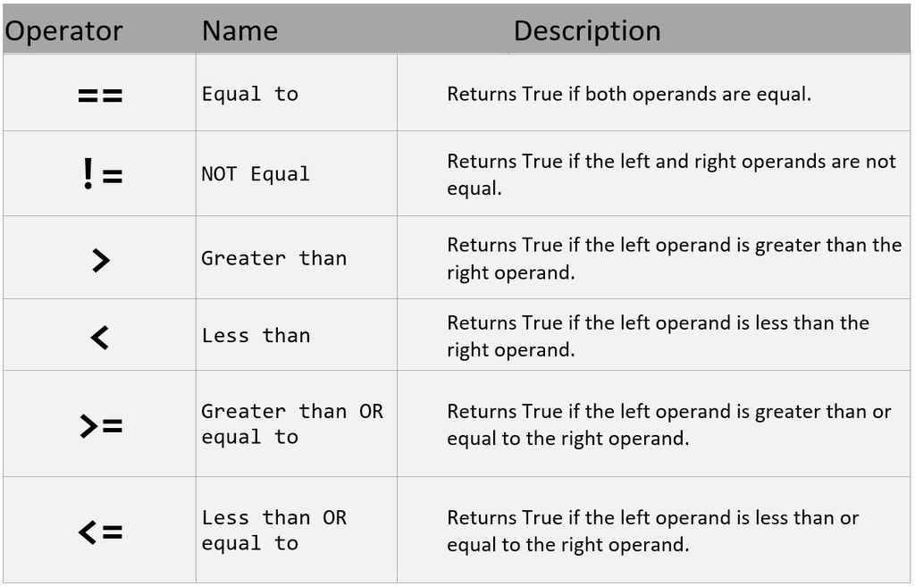

**Tip:** Don't forget to increase the variable each iteration. If there is no way to escape the loop then it is an infinite loop! Or is that your intention?

# While True

## In a way, the good infinite loop!

```python
while True:
    try:
      LowNum = int(input("What is the LOW number in the range?"))
      return(LowNum)
    except ValueError:
      print("Invalid number. PLease try again")
```

### "While True" with try/except will evaluate the statements and try to stop the program from crashing.

### Python will "Try" to execute the statements AND Return LowNum if everything is alright.

### EXCEPT (ValueError thrown) if user trys to enter anything but an integer! We catch the error and give the user another try.

## while True with breaks & continue

While loops can be broken out of using the 'break' keyword or can use the 'continue' keyword to contine to the next line in the loop.

```python
while True:
    myLowNum = getLowNumber()
    myHighNum = getHighNumber()
    theNumber = randint(myLowNum, myHighNum)
    theGuess(theNumber)

    tryAgain = input("Try again?")

    if tryAgain == "y" or tryAgain == "Y":
        continue
    else:
        print("\nSorry to see you go...\n")
        print("\nFor happiness, the last ANSWER was:",theNumber,"\n\n")
        break
```

Resources used and great for deeper research:

1. W3Schools.com [While Loops](https://www.w3schools.com/python/python_while_loops.asp)
2. StackOverflow. [What does "while True" mean in Python?](https://stackoverflow.com/questions/3754620/what-does-while-true-mean-in-python)
3. Real Python - [Guide to the "while" Loops (Indefinite Iteration)](https://realpython.com/python-while-loop/)